The most recent update of this html document occurred: Fri Dec 2 08:09:01 2016

```r
library(knitr)

library(ggplot2)
library(reshape)
library(DESeq2)
library(genefilter)
library(CHBUtils)
library(gtools)
library(gridExtra)
library(devtools)
library(dplyr)
library(isomiRs)
library(pheatmap)

knitr::opts_chunk$set(tidy=TRUE, highlight=TRUE, dev="png", fig.width=6,fig.heigh=6,
               cache=TRUE, highlight=TRUE, autodep=TRUE,
               warning=FALSE, error=FALSE,
               message=FALSE, prompt=TRUE, comment='', fig.cap='', bootstrap.show.code=FALSE)

root_path = "~/orch/scratch/simulator/hd/srna/final"
root_file = file.path(root_path, "srna_out_files")
dir.create(root_file, showWarnings = FALSE)

fns = list.files(root_path, recursive=T, full.names = TRUE)

metadata_fn =  list.files(file.path(root_path,"2016-11-20_srna","report"), pattern = "summary.csv$",recursive = T, full.names = T)
metadata = read.csv(metadata_fn, row.names=1)
condition = names(metadata)[1]
design = metadata
formula = ~ condition # modify this to get your own formula, it should be a column in your metadata
isde=FALSE # turn this true to make DE ananlysis
```

# Exploratory analysis

In this section we will see descriptive figures about quality of the data, reads with adapter, reads mapped to miRNAs, reads mapped to other small RNAs.

## size distribution

After adapter removal, we can plot the size distribution of the small RNAs.

```r
> files = fns[grepl("trimming_stats", fns)]
> isadapter = length(files) > 0
```

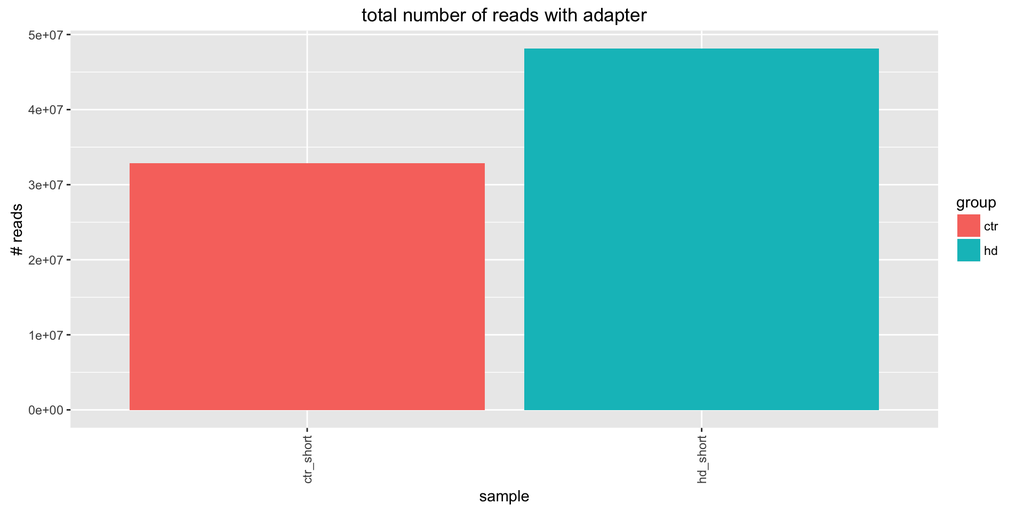

```r
> names(files) = sapply(files, function(x) {
+     gsub("-ready.trimming_stats", "", basename(x))
+ })
>
>
> tab = data.frame()
> for (sample in rownames(metadata)) {
+     d = read.table(files[sample])
+     tab = rbind(tab, d %>% mutate(sample = sample, group = metadata[sample,
+         condition]))
+ }
>
>
> reads_adapter = tab %>% group_by(sample, group) %>% summarise(total = sum(V2))
> ggplot(reads_adapter, aes(x = sample, y = total, fill = group)) + geom_bar(stat = "identity",
+     position = "dodge") + ggtitle("total number of reads with adapter") + ylab("# reads") +
+     theme(axis.text.x = element_text(angle = 90, vjust = 0.5, hjust = 1))
```

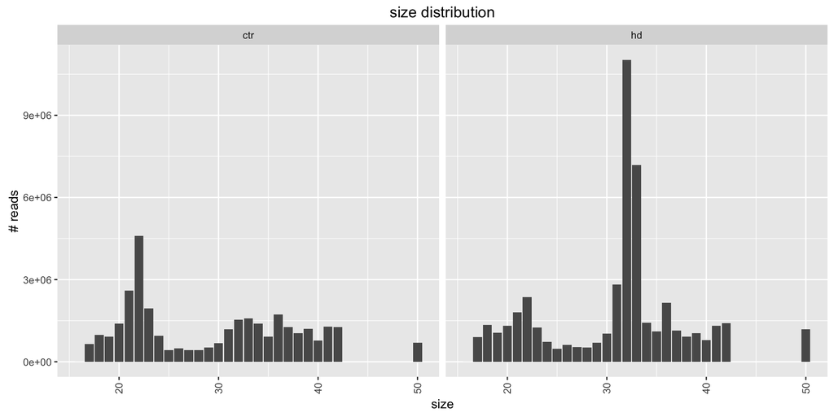

```r
> ggplot(tab, aes(x = V1, y = V2, group = sample)) + geom_bar(stat = "identity",
+     position = "dodge") + facet_wrap(~group, ncol = 2) + ggtitle("size distribution") +
+     ylab("# reads") + xlab("size") + theme(axis.text.x = element_text(angle = 90,
+     vjust = 0.5, hjust = 1))
```

```r
> files = fns[grepl("mirbase-ready", fns)]
> ismirbase = length(files) > 0
> mirdeep2_files = fns[grepl("novel-ready", fns)]
> ismirdeep2 = length(mirdeep2_files) > 0
```

## miRNA

### total miRNA expression annotated with mirbase

```r
> names(files) = sapply(files, function(x) {
+     gsub("-mirbase-ready.counts", "", basename(x))
+ })
>
> obj <- IsomirDataSeqFromFiles(files = files[rownames(design)], design = design,
+     header = T, skip = 0)
```

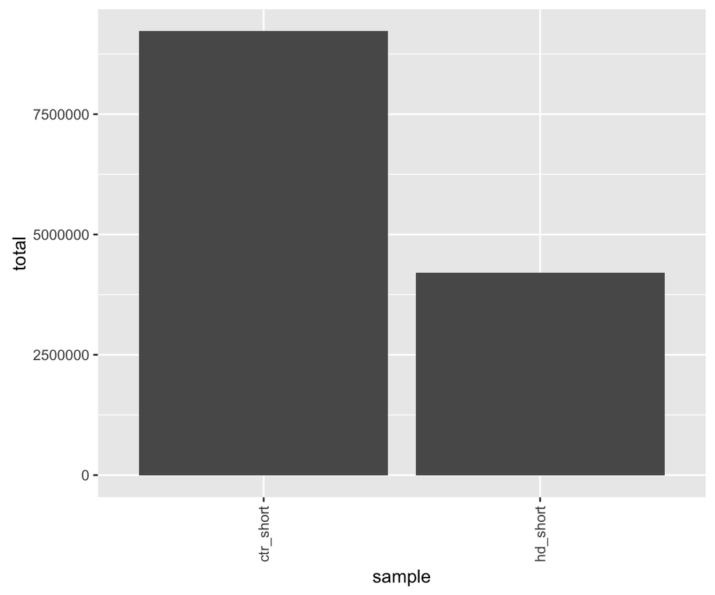

```r
> ggplot(data.frame(sample = colnames(counts(obj)), total = colSums(counts(obj)))) +
+     geom_bar(aes(x = sample, y = total), stat = "identity") + theme(axis.text.x = element_text(angle = 90,
+     vjust = 0.5, hjust = 1))
```

```r
> mirna_step <- as.data.frame(colSums(counts(obj)))
```

### Distribution of mirna expression

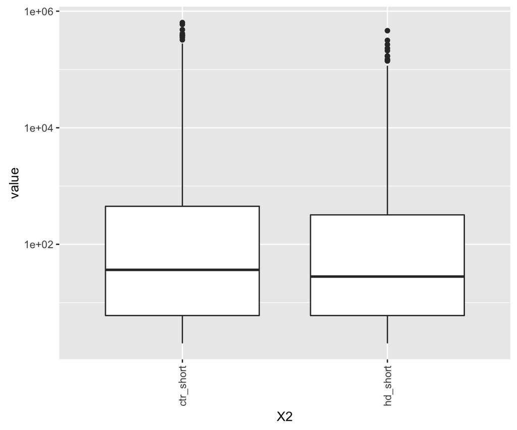

```r
> ggplot(melt(counts(obj))) + geom_boxplot(aes(x = X2, y = value)) + scale_y_log10() +
+     theme(axis.text.x = element_text(angle = 90, vjust = 0.5, hjust = 1))
```

### cumulative distribution of miRNAs

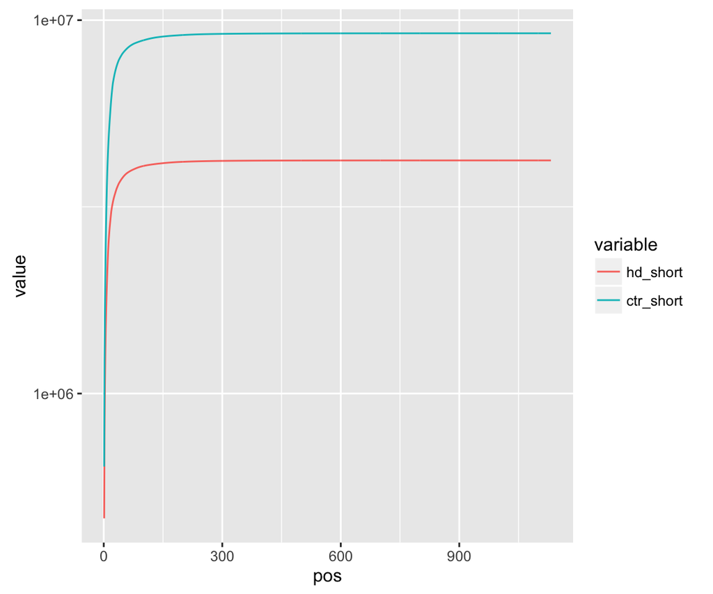

```r
> cs <- as.data.frame(apply(counts(obj), 2, function(x) {
+     cumsum(sort(x, decreasing = T))
+ }))
> cs$pos <- 1:nrow(cs)
>
> ggplot((melt(cs, id.vars = "pos"))) + geom_line(aes(x = pos, y = value, color = variable)) +
+     scale_y_log10()
```

### Clustering

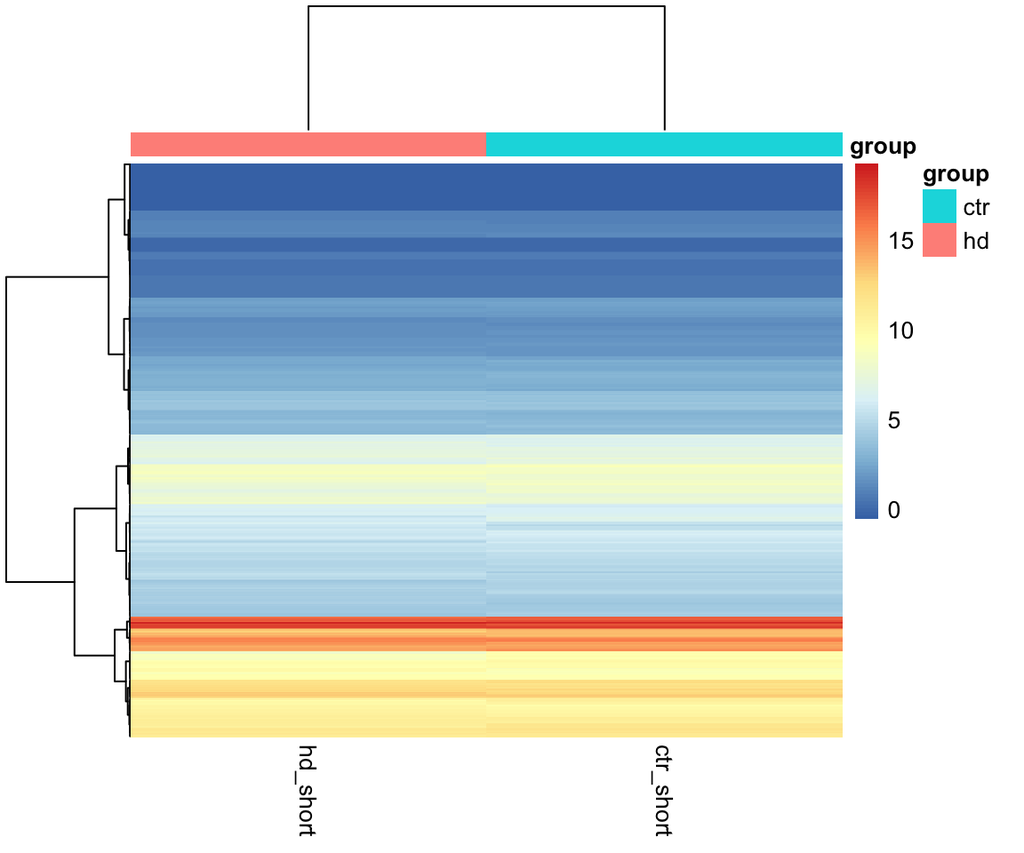

```r
> counts = counts(obj)
> dds = DESeqDataSetFromMatrix(counts[rowSums(counts > 0) > 0, ], colData = design,
+     design = ~1)
> vst = rlog(dds)
>
> pheatmap(assay(vst), annotation_col = design[, 1, drop = FALSE], show_rownames = F,
+     clustering_distance_cols = "correlation", clustering_method = "ward.D")
```

### complexity

```r
> kable(as.data.frame(colSums(counts > 10)))
```

|  | colSums(counts > 10) |
| --- | --- |
| hd_short | 577 |
| ctr_short | 701 |

## novel miRNA by mirdeep2

### total miRNA expression

```r
> files = mirdeep2_files
>
> names(files) = sapply(files, function(x) {
+     gsub("-novel-ready.counts", "", basename(x))
+ })
>
> obj_mirdeep <- IsomirDataSeqFromFiles(files = files[rownames(design)], design = design,
+     header = T)
```

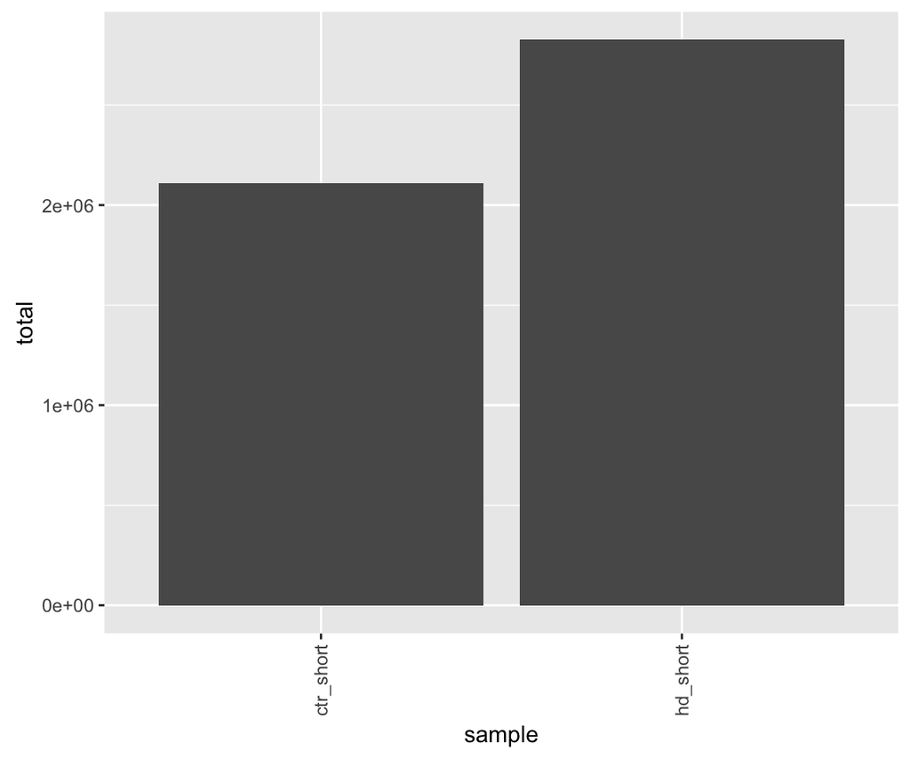

```r
> ggplot(data.frame(sample = colnames(counts(obj_mirdeep)), total = colSums(counts(obj_mirdeep)))) +
+     geom_bar(aes(x = sample, y = total), stat = "identity") + theme(axis.text.x = element_text(angle = 90,
+     vjust = 0.5, hjust = 1))
```

```r
> mirna_step <- as.data.frame(colSums(counts(obj)))
```

### Distribution of mirna expression

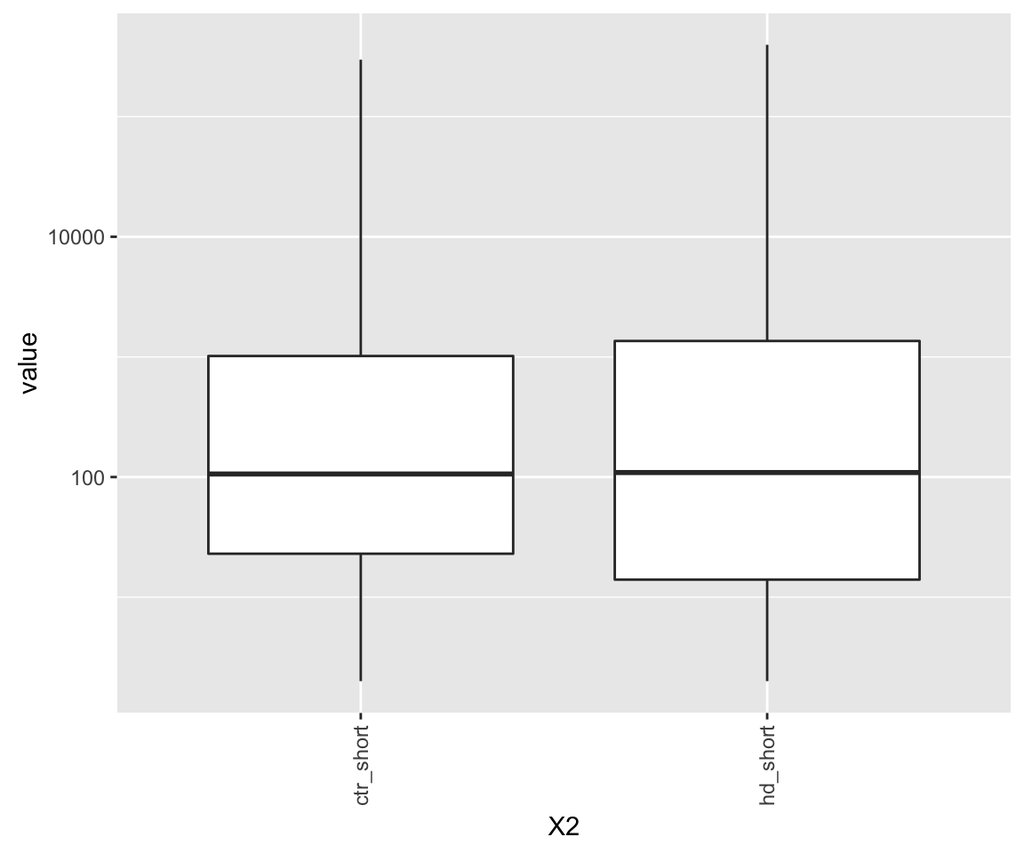

```r
> ggplot(melt(counts(obj_mirdeep))) + geom_boxplot(aes(x = X2, y = value)) + scale_y_log10() +
+     theme(axis.text.x = element_text(angle = 90, vjust = 0.5, hjust = 1))
```

### cumulative distribution of miRNAs

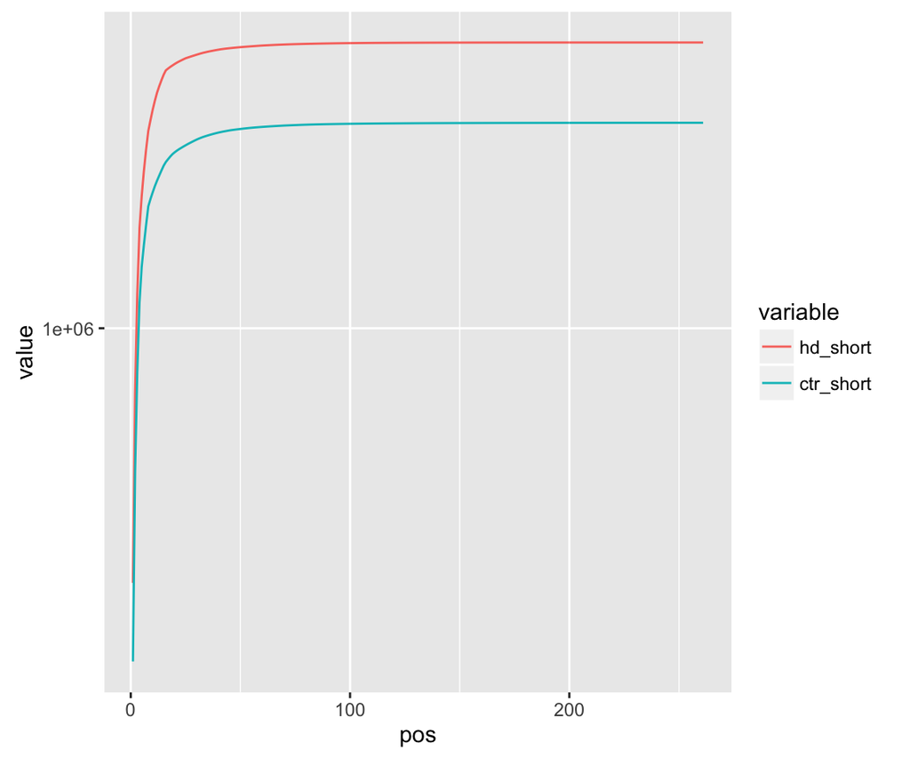

```r
> cs <- as.data.frame(apply(counts(obj_mirdeep), 2, function(x) {
+     cumsum(sort(x, decreasing = T))
+ }))
> cs$pos <- 1:nrow(cs)
>
> ggplot((melt(cs, id.vars = "pos"))) + geom_line(aes(x = pos, y = value, color = variable)) +
+     scale_y_log10()
```

### Clustering

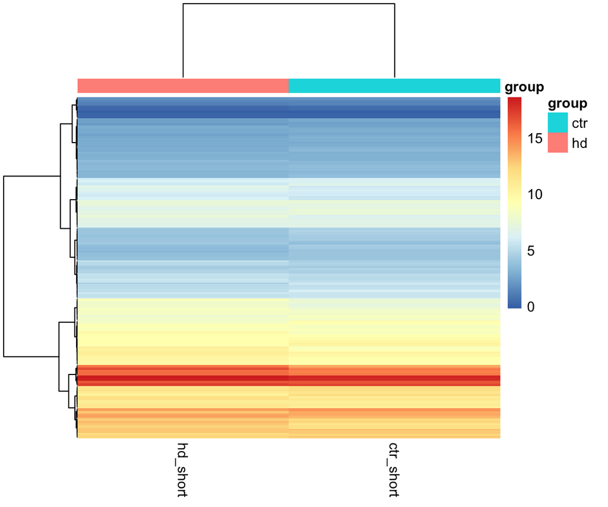

```r
> counts = counts(obj_mirdeep)
> dds = DESeqDataSetFromMatrix(counts[rowSums(counts > 0) > 0, ], colData = design,
+     design = ~1)
> vst = rlog(dds)
>
> pheatmap(assay(vst), annotation_col = design[, 1, drop = FALSE], show_rownames = F,
+     clustering_distance_cols = "correlation", clustering_method = "ward.D")
```

### complexity

```r
> kable(as.data.frame(colSums(counts > 10)))
```

|  | colSums(counts > 10) |
| --- | --- |
| hd_short | 181 |
| ctr_short | 230 |

## Others small RNA

The data was analyzed with [seqcluster](http://seqcluster.readthedocs.org/)

This tools used all reads, uniquely mapped and multi-mapped reads. The first step is to cluster sequences in all locations they overlap. The second step is to create meta-clusters: is the unit that merge all clusters that share the same sequences. This way the output are meta-clusters, common sequences that could come from different region of the genome.

### genome covered

```r
> fn_json = list.files(file.path(root_path, "2016-11-20_srna", "seqcluster"),
+     pattern = "seqcluster.json", recursive = T, full.names = T)
> seq_dir = dirname(fn_json)
>
> isseqcluster = length(fn_json) > 0
> # cov_stats <- read.table(file.path(root_path, '..', 'align',
> # 'seqs_rmlw.bam_cov.tsv'),sep='\t',check.names = F)
>
> # kable(cov_stats[cov_stats$V1=='genome',] %>%
> # dplyr::select(coverage=V2,ratio_genome=V5), row.names = FALSE)
```

### classification

Number of reads in the data after each step:

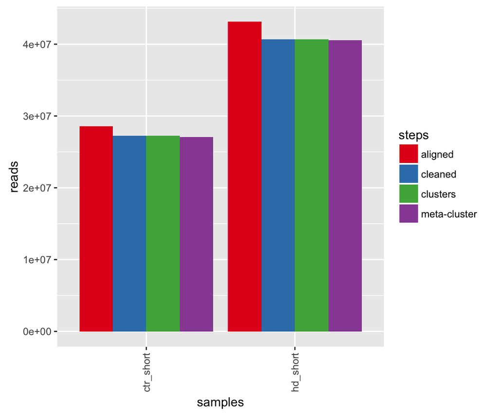

```r
> reads_stats <- read.table(file.path(seq_dir, "read_stats.tsv"), sep = "\t",
+     check.names = F)
> ggplot(reads_stats, aes(x = V2, y = V1, fill = V3)) + geom_bar(stat = "identity",
+     position = "dodge") + labs(list(x = "samples", y = "reads")) + scale_fill_brewer("steps",
+     palette = "Set1") + theme(axis.text.x = element_text(angle = 90, vjust = 0.5,
+     hjust = 1))
```

```r
> clus <- read.table(file.path(seq_dir, "counts.tsv"), header = T, sep = "\t",
+     row.names = 1, check.names = FALSE)
> ann <- clus[, 2]
> toomany <- clus[, 1]
> clus_ma <- clus[, 3:ncol(clus)]
> clus_ma = clus_ma[, row.names(design)]
```

Check complex meta-clusters: This kind of events happen when there are small RNA over the whole genome, and all repetitive small rnas map to thousands of places and sharing many sequences in many positions. If any meta-cluster is > 40% of the total data, maybe it is worth to add some filters like: minimum number of counts `-e` or `--min--shared` in `seqcluster prepare`

```r
> library(edgeR)
> clus_ma_norm = cpm(DGEList(clus_ma), normalized.lib.sizes = TRUE)
> head(clus_ma_norm[toomany > 0, ])
```

```
     hd_short ctr_short
```

### complexity

```r
> kable(as.data.frame(colSums(clus_ma > 10)))
```

|  | colSums(clus_ma > 10) |
| --- | --- |
| hd_short | 1160 |
| ctr_short | 1176 |

### Contribution by class

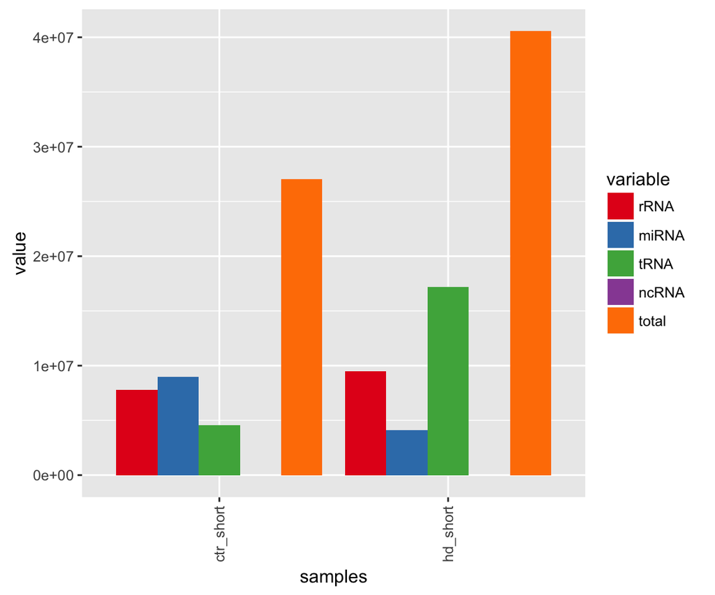

```r
> rRNA <- colSums(clus_ma[grepl("rRNA", ann) & grepl("miRNA", ann) == F, ])
> miRNA <- colSums(clus_ma[grepl("miRNA", ann), ])
> tRNA <- colSums(clus_ma[grepl("tRNA", ann) & grepl("rRNA", ann) == F & grepl("ncRNA",
+     ann) == F & grepl("miRNA", ann) == F, ])
> rmsk <- colSums(clus_ma[grepl("ncRNA", ann) & grepl("rRNA", ann) == F & grepl("miRNA",
+     ann) == F, ])
> total <- colSums(clus_ma)
>
> dd <- data.frame(samples = names(rRNA), rRNA = rRNA, miRNA = miRNA, tRNA = tRNA,
+     ncRNA = rmsk, total = total)
> ggplot(melt(dd)) + geom_bar(aes(x = samples, y = value, fill = variable), stat = "identity",
+     position = "dodge") + scale_fill_brewer(palette = "Set1") + theme(axis.text.x = element_text(angle = 90,
+     vjust = 0.5, hjust = 1))
```

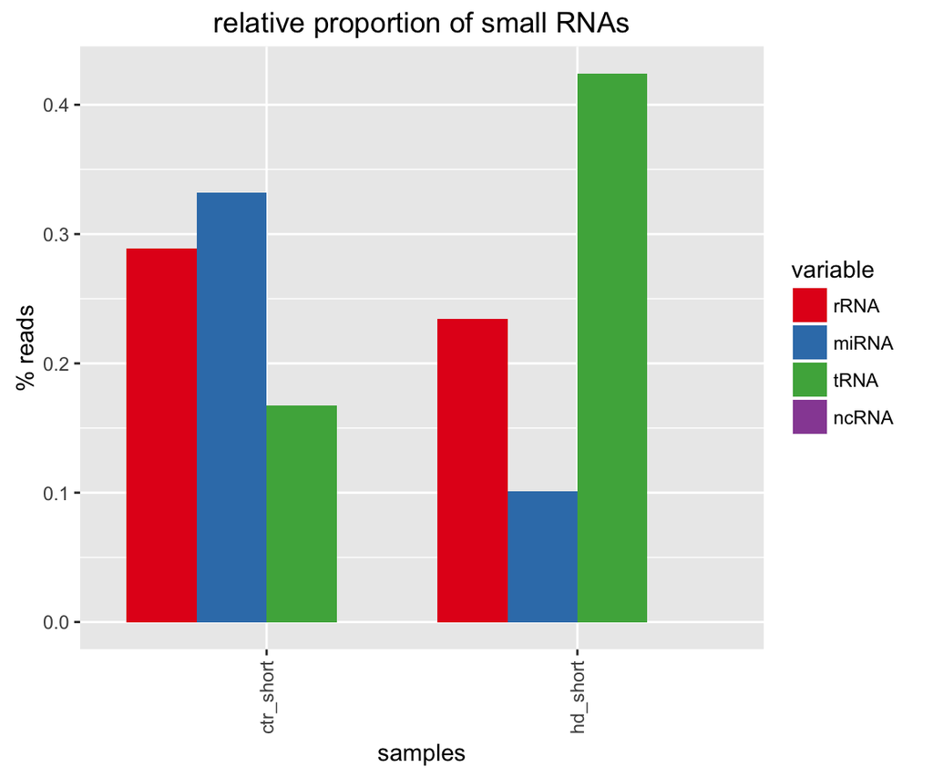

```r
> dd_norm = dd
> dd_norm[, 2:5] = sweep(dd[, 2:5], 1, dd[, 6], "/")
> ggplot(melt(dd_norm[, 1:5])) + geom_bar(aes(x = samples, y = value, fill = variable),
+     stat = "identity", position = "dodge") + scale_fill_brewer(palette = "Set1") +
+     theme(axis.text.x = element_text(angle = 90, vjust = 0.5, hjust = 1)) +
+     labs(list(title = "relative proportion of small RNAs", y = "% reads"))
```

```r
> # size_clus <- read.table(file.path(root_path, '..', 'seqcluster',
> # 'cluster', 'size_counts.tsv'),sep='\t',check.names = F)
```